# STAT 341/641 Lab: Week Six

Firas Fakih

Sunday March 8 2020

**STAT 341/641:** Intro to EDA and Statistical Computing  
**Lab #5:** Rejection Sampling and the Bootstrap  
**Teaching Assistant:** “Erin Zhang”

**Directions:** You will use the lab time to complete this assignment.

#**Task: Practice rejection sampling and the bootstrap**

##1: Suppose we would like to obtain samples from a probability density that satisfies
$$f(x) \propto \exp\left\{-x^2/2 \right\}(\sin(6x)^2 + 3\cos(x)^2).$$
The symbol $\propto$ indicates that the density is proportional to $\exp\left\{-x^2/2 \right\}(\sin(6x)^2 + 3\cos(x)^2)$. In general, two quantities $a$ and $b$ are proportional if $a = kb$ where $k$ is called the constant of proportionality. For probability distributions, we frequently know the numerator, but not the denominator.

Anyway, find a number $M \geq 1$ such that the envelope condition holds for proposal distribution $g(x) = N(0,1).$ Recall the envelope condition is $f(x) \leq M g(x)$ for all $x$.

As a hint, look at the code chunk below. Try looping over values for $M$. Choose the smallest value of $M$ that satisfies the condition.

**Solution:**

```r
myseq <- seq(from = -4, to = 4, by = .1)
f <- function(x){
  exp(-x^2/2)*(sin(6*x)^2 + 3*cos(x)^2)
}
M <- 1
while (!all(f(myseq) < M * dnorm(myseq))) {
  M = M+1

}
M
```

```
## [1] 10
```

**Solution:**

```r
mynum <- 0
N <- 1000
fsamples <- NULL
M <- 10
i <- 0
while(mynum < N){
  i = i+1
  ## sample from the proposal
  mysamp <- rnorm(1)

  ## compute r
  myr = (f(mysamp)) / (M*dnorm(mysamp))

  if(sample(c(0,1),1,prob = c(1-myr,myr)) == 1){
    ## record the sample
    fsamples <- c(fsamples, mysamp)
    mynum <- mynum + 1
  }

}
```

##3: Plot histograms of 1,000 samples from $Mg(x)$ and $f(x)$. Use pastel colors with a low alpha (high level of transparency) in order to overlay the two distributions on the same plot.

**Solution:**

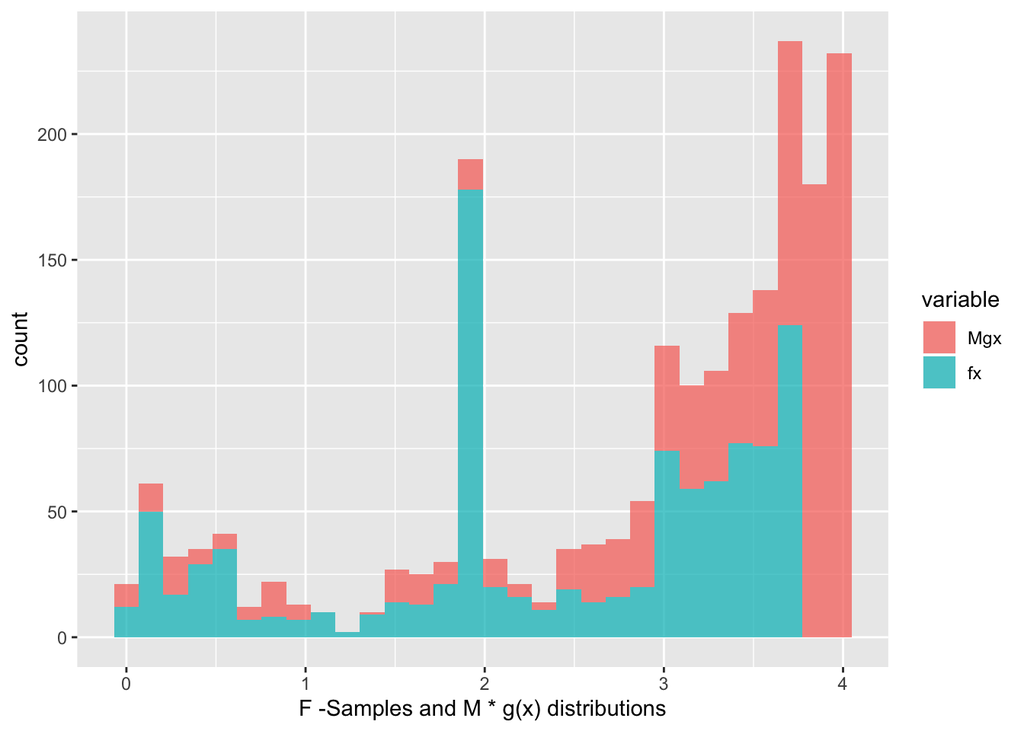

```r
library(ggplot2)
library(reshape2)
fx <- f(fsamples)
Mgx <- M * dnorm(fsamples)
data <- as.data.frame(cbind(Mgx,fx))
data.melt <- melt(data)
ggplot(data = data.melt, aes(value,fill = variable)) + geom_histogram(alpha = 0.75) +
  labs (x = "F -Samples and M * g(x) distributions")
```

**Solution:**

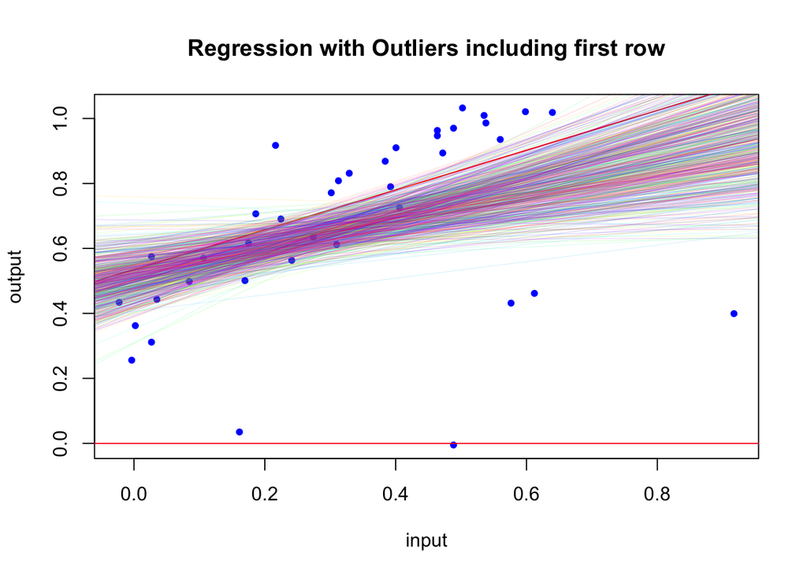

```r
set.seed(641)
outs <- read.csv("/Users/firasfakih/Desktop/STAT341/Data/rousseeuw_outlier_set1.csv")
R <- 1000
beta1 <- matrix(0,R,2)
beta2 <- matrix(0,R,2)
for (j in c(1:R)){
  ## sample indices to make bootstrap sample
  inds <- sample(c(1:nrow(outs)),size = nrow(outs),replace = T)
  ## compute the regression
  res <- lm(Y ~ X, data = outs[inds,])

  if (1 %in% inds){
    beta1[j,] <- coef(res)
  }
  else{
    beta2[j,] <- coef(res)
  }
}

betaMean1 <- colMeans(beta1)
betaMean2 <- colMeans(beta2)


mycols <- rainbow(R,alpha = .20)

plot(outs,typ="n",xlab="input",ylab="output",main = "Regression with Outliers including first row")
points(outs,pch = 20, col="blue")
abline(res, col = "red")
for (j in c(1:R)){
  abline(a = beta1[j,1], b = beta1[j,2], col=mycols[j], lwd = .5)
}
```

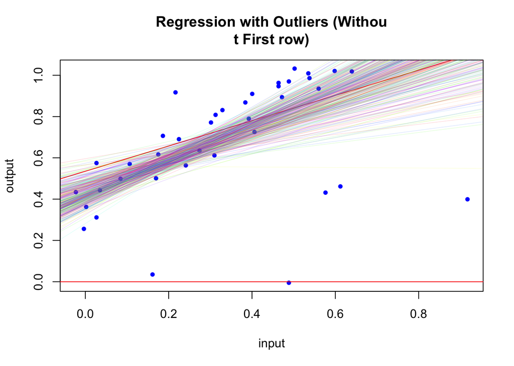

```r
# Bootstrap without first row

plot(outs,typ="n",xlab="input",ylab="output",main = "Regression with Outliers (Withou
t First row)")
points(outs,pch = 20, col="blue")
abline(res, col = "red")
for (j in c(1:R)){
abline(a = beta2[j,1], b = beta2[j,2], col = mycols[j], lwd = .5)
}
```